# Chapter 07: Analysis of Function: Sentence Modes and Nuclear Contours without a Register Tier

It is clear that there is little relationship between the pitch accent and mode when the register tier is discounted. However, looking at the raw data for the phrase-level phonology, it looks like L% boundaries are more commonly associated with questions than declaratives.

Therefore, it might be worth looking at the nuclear contour as a whole in this data set.

## Nuclear contour

### Nuclear contour by Speaker

Distibution by speaker of nuclear contours in M-corpus (adjusted)

| speaker | L*H % | L*H L% | L*H H% | L*H HL% | >H* L% | H* L% |
| --- | --- | --- | --- | --- | --- | --- |
| F5 | 36 | 14 | 7 | 2 | 0 | 0 |
| F6 | 53 | 4 | 3 | 0 | 0 | 0 |
| F12 | 21 | 38 | 1 | 0 | 0 | 0 |
| F15 | 53 | 3 | 4 | 0 | 0 | 0 |
| F16 | 59 | 0 | 1 | 0 | 0 | 0 |
| F17 | 57 | 2 | 1 | 0 | 0 | 0 |
| M4 | 55 | 0 | 5 | 0 | 0 | 0 |
| M5 | 60 | 0 | 0 | 0 | 0 | 0 |
| M8 | 27 | 13 | 0 | 0 | 5 | 2 |
| M9 | 38 | 22 | 0 | 0 | 0 | 0 |
| M10 | 44 | 16 | 0 | 0 | 0 | 0 |
| Total | 503 | 112 | 22 | 2 | 5 | 2 |

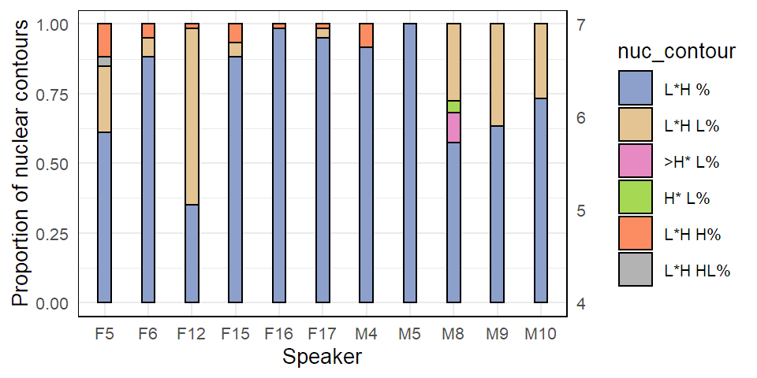

### Nuclear contour by Sentence Mode

Distibution by mode of nuclear contours in M-corpus (adjusted)

| mode | L*H % | L*H L% | L*H H% | L*H HL% | >H* L% | H* L% |
| --- | --- | --- | --- | --- | --- | --- |
| MDC | 139 | 17 | 0 | 0 | 2 | 2 |
| MWH | 148 | 17 | 0 | 0 | 0 | 0 |
| MYN | 124 | 29 | 5 | 0 | 2 | 0 |
| MDQ | 93 | 49 | 17 | 2 | 1 | 0 |
| Total | 504 | 112 | 22 | 2 | 5 | 2 |

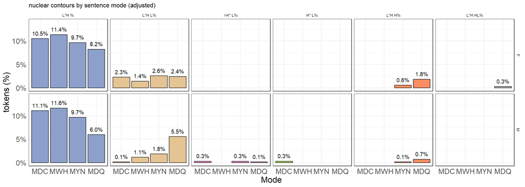

It appears that the male speakers are more likely to begin using L% across the question mode hierarchy more than the female speakers. There are not enough speakers, I believe, however, to justify this as a general conclusion, especially as it is only M8, M9, and M10 who do this.

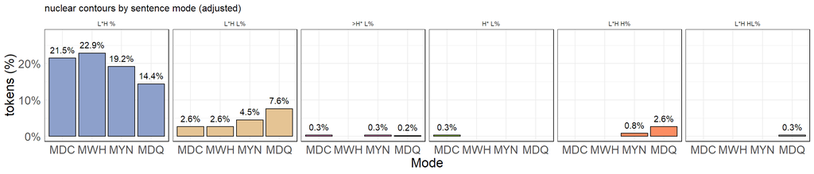

#### Chi Squared test of association using adjusted data for nuc_contour

```
##
##  Pearson's Chi-squared test
##
## data:  .
## X-squared = 87.277, df = 15, p-value = 3.186e-12
```

The overall pattern suggest that L% is more common among YNQs and and DCQs. However, I don’t think that the L% is used to signal a question. I think that, as with the A&H corpus, L% is used when the speaker indicates there is a conflict of expectation of shared knowledge between the speaker and listener. Thus in questions like “You live in the valley?” and “Do you live in the valley?”, speaker can use the L% to indicate that the propositional content conflicts with what he or she had previously believed; i.e., it indicates surprise. In a reciprocal manner, in the declaratives of the A&H corpus (and here), the use of an L% indicates that the speaker is indicating surprise that the listener does not already share the knowledge. (i.e. “Where do you live?…”I live in the valley [L%] (and I assumed you already knew that / and you should know that already.”) … Perhaps the best way to think of this is as the surprise~redundancy strategy, with the conflict of expectations expressing redundancy in the declaratives (“This should not be news to you.”) and surprise in the questions (“I did not know this at all!”).

Bearing in mind that the >H* L% and H* L% contours all belong to M8 and may represent transitional code switching, we can re produce the chi squared test without those contours.

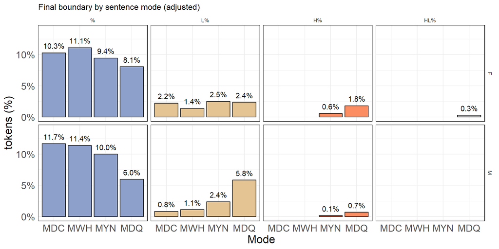

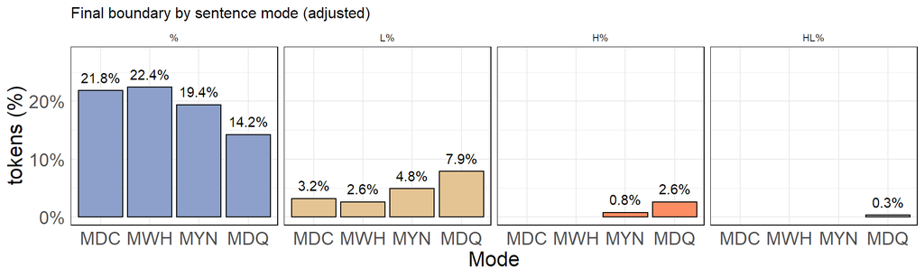

#### Chi Squared test of association using adjusted data only for H% versus %.

```
##
##  Pearson's Chi-squared test
##
## data:  .
## X-squared = 47.982, df = 3, p-value = 2.148e-10
```

However, if we run this again, using only the female data…

```
##
##  Pearson's Chi-squared test
##
## data:  .
## X-squared = 30.196, df = 3, p-value = 1.255e-06
```

… compared with the male data…

```
##
##  Pearson's Chi-squared test
##
## data:  .
## X-squared = 19.986, df = 3, p-value = 0.0001709
```

The data suggest that there is statistically significant correlation between H% and sentence mode.

#### Chi Squared test of association using adjusted data only for L% versus %.

```
## Using Adjusted Data and Montecarlo simulation:
```

```
##
##  Pearson's Chi-squared test
##
## data:  .
## X-squared = 38.33, df = 3, p-value = 2.406e-08
```

However, if we run this again, using only the female data…

```
##
##  Pearson's Chi-squared test
##
## data:  .
## X-squared = 4.5226, df = 3, p-value = 0.2103
```

… compared with the male data…

```
##
##  Pearson's Chi-squared test
##
## data:  .
## X-squared = 61.443, df = 3, p-value = 2.89e-13
```

The results give the impression that this is a feature of male rather than female speech. However, only three out of the five male speakers do this, so it is unlikely to be a features of “male speech”. More likely, different speakers interpreted the motivation behind the prompt statement and their response, in terms of the intonational phonology, reflects whether or not they chose to use a surprise/redundancy falling boundary.

#### GLMM test of difference between nuc_contour as a fn of mode.

```
## Generalized linear mixed model fit by maximum likelihood (Laplace
##   Approximation) [glmerMod]
##  Family: binomial  ( logit )
## Formula: nuc_contour ~ mode + (1 | speaker)
##    Data: m_corpus
## Control:
## glmerControl(optimizer = "optimx", calc.derivs = FALSE, optCtrl = list(method = "nlminb",
##     starttests = FALSE, kkt = FALSE))
##
##      AIC      BIC   logLik deviance df.resid
##    494.5    516.8   -242.3    484.5      634
##
## Scaled residuals:
##     Min      1Q  Median      3Q     Max
## -3.1644 -0.4332 -0.2061 -0.0676  3.5230
##
## Random effects:
##  Groups  Name        Variance Std.Dev.
##  speaker (Intercept) 3.012    1.736
## Number of obs: 639, groups:  speaker, 11
##
## Fixed effects:
##             Estimate Std. Error z value Pr(>|z|)
## (Intercept)  -2.7167     0.5987  -4.537 5.70e-06 ***
## modeMWH      -0.3653     0.3803  -0.961   0.3367
## modeMYN       0.7663     0.3402   2.253   0.0243 *
## modeMDQ       2.2515     0.3456   6.515 7.27e-11 ***
## ---
## Signif. codes:  0 '***' 0.001 '**' 0.01 '*' 0.05 '.' 0.1 ' ' 1
##
## Correlation of Fixed Effects:
##         (Intr) modMWH modMYN
## modeMWH -0.283
## modeMYN -0.336  0.502
## modeMDQ -0.378  0.487  0.584
```

isSingular(nuc_contour_model, tol=1e-5) –> FALSE

ANOVA of model and null model, assuming no register tier.

|  | npar | AIC | BIC | logLik | deviance | Chisq | Df | Pr(>Chisq) |
| --- | --- | --- | --- | --- | --- | --- | --- | --- |
| nuc_contour_model_null | 2 | 563.9605 | 572.8803 | -279.9802 | 559.9605 | NA | NA | NA |
| nuc_contour_model | 5 | 494.5019 | 516.8014 | -242.2509 | 484.5019 | 75.45861 | 3 | 2.889425e-16 |

Predicted probabilities of nuc_contour, nuc_contour ~ mode + (1 | speaker)

| mode | predicted | std.error | conf.low | conf.high |
| --- | --- | --- | --- | --- |
| MDC | 0.062 | 0.5987 | 0.02 | 0.1761 |
| MWH | 0.0439 | 0.6119 | 0.0136 | 0.1321 |
| MYN | 0.1245 | 0.5809 | 0.0436 | 0.3075 |
| MDQ | 0.3857 | 0.567 | 0.1713 | 0.6561 |

$mode

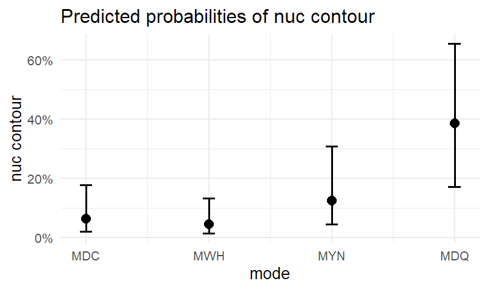

Conditional and marginal R<sup>2</sup> of model

| R2_conditional | R2_marginal | optional |
| --- | --- | --- |
| 0.55 | 0.14 | FALSE |

summary of model: nuc_contour ~ mode + (1 | speaker)

| term | estimate | conf.low | conf.high | std.error | z.value | p.value |
| --- | --- | --- | --- | --- | --- | --- |
| (Intercept) | 0.066 | 0.02 | 0.214 | 0.040 | -4.537 | 5.7e-06 |
| modeMWH | 0.694 | 0.329 | 1.462 | 0.264 | -0.961 | 0.3367 |
| modeMYN | 2.152 | 1.105 | 4.191 | 0.732 | 2.253 | 0.0243 |
| modeMDQ | 9.502 | 4.827 | 18.7 | 3.284 | 6.515 | 7.3e-11 |

## Intercepts and Pairwise comparisons

b0 for nuc_contour ~ mode + (1 | speaker)

| intercept | estimate | conf.low | conf.high | std.error | z.value | p.value |
| --- | --- | --- | --- | --- | --- | --- |
| modeMDC | 0.066 | 0.02 | 0.214 | 0.040 | -4.537 | 5.7e-06 |
| modeMWH | 0.046 | 0.014 | 0.152 | 0.028 | -5.037 | 4.7e-07 |
| modeMYN | 0.142 | 0.046 | 0.444 | 0.083 | -3.357 | 7.9e-04 |
| modeMDQ | 0.628 | 0.207 | 1.908 | 0.356 | -0.821 | 0.412 |

b1 for nuc_contour ~ mode + (1 | speaker)

| intercept | slope | estimate | conf.low | conf.high | std.error | z.value | p.value |
| --- | --- | --- | --- | --- | --- | --- | --- |
| modeMDC | modeMWH | 0.694 | 0.329 | 1.462 | 0.264 | -0.961 | 0.337 |
| modeMDC | modeMYN | 2.152 | 1.105 | 4.191 | 0.732 | 2.253 | 0.024 |
| modeMDC | modeMDQ | 9.502 | 4.827 | 18.7 | 3.284 | 6.515 | 7.3e-11 |
| modeMWH | modeMYN | 3.101 | 1.528 | 6.293 | 1.120 | 3.134 | 0.002 |
| modeMWH | modeMDQ | 13.7 | 6.646 | 28.2 | 5.048 | 7.097 | 1.3e-12 |
| modeMYN | modeMDQ | 4.416 | 2.392 | 8.151 | 1.381 | 4.749 | 2.0e-06 |